# Proyecto Final: Reporte Histórico ENVIPE

Esto indica que, en comparación con el promedio nacional, las personas en Querétaro tienden a sentirse más seguras y confiadas en sus relaciones de amistad.

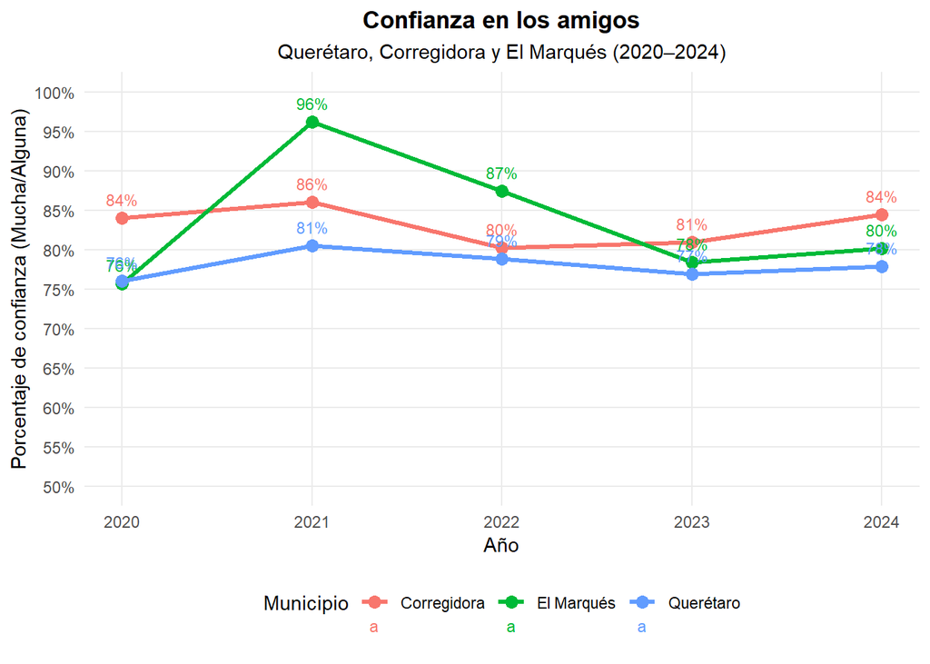

**Nota:** Los datos expuestos en la gráfica correspondiente a el municipio de El Marqués anteriores al año 2024 no representan con exactitud la información esperada, esto debido a la muestra tomada para el ENVIPE en sus ediciones 2021, 2022, 2023 y 2024, donde si bien El Marqués se considera una Área Urbana de Interés existe una diferencia abismal en el número de datos recopilados en estos años a los recopilados en 2025, pasando de una a once localidades principales para la alta de datos, lo que para los años anteriores a la ENVIPE 2025 significa menos cantidad de datos y a su vez anomalías al aplicar su factor de expansión correspondiente.

**Análisis**

La gráfica muestra el nivel de confianza en los amigos en los municipios de Querétaro, Corregidora y El Marqués entre 2020 y 2024. En los tres municipios, la mayoría de las personas respondió que tiene “mucha” o “alguna” confianza en sus amistades, lo que refleja relaciones sociales positivas y cercanas.

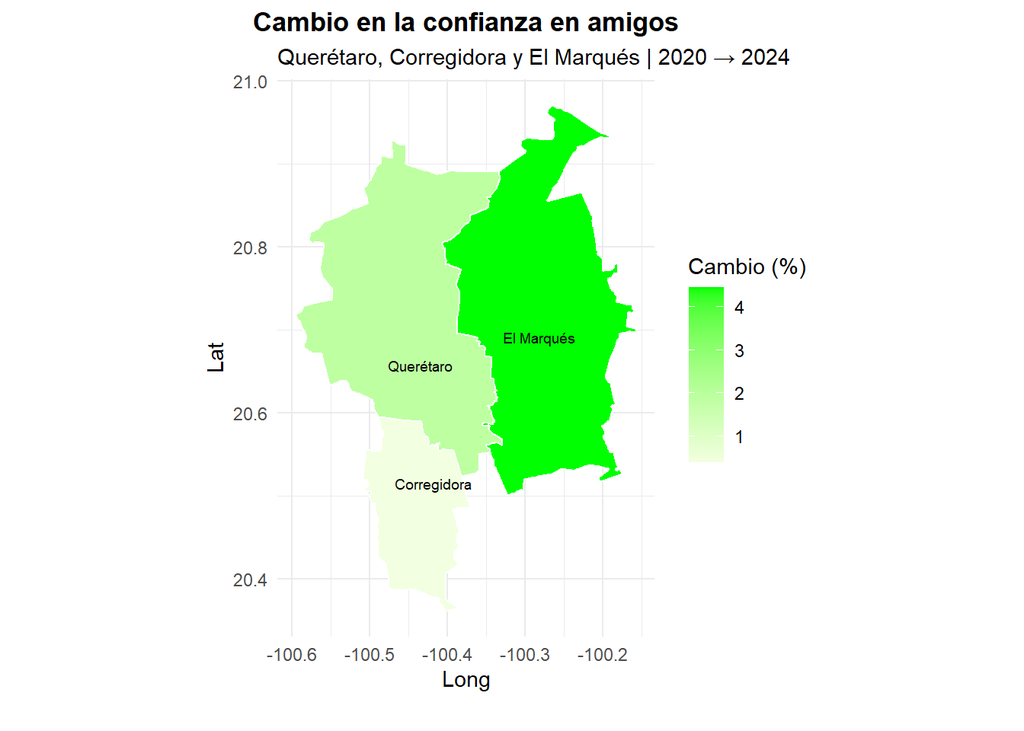

**Análisis**

La gráfica muestra cómo cambió la confianza en amigos entre 2020 y 2024 en los municipios de Querétaro, Corregidora y El Marqués. Los colores verdes representan un aumento en la confianza.

**Conclusión general**

Las gráficas muestran que la confianza en los amigos se mantuvo alta y relativamente estable entre 2020 y 2024 tanto en Querétaro como en el resto del país.

En general, la mayoría de las personas respondió tener “mucha” o “alguna” confianza en sus amistades, lo que refleja la importancia de las relaciones personales como fuente de apoyo y convivencia social.

Querétaro presentó niveles de confianza ligeramente superiores al promedio nacional durante casi todo el periodo analizado. Además, municipios como Corregidora destacaron por mantener porcentajes particularmente altos y estables.

Aunque existieron algunas diferencias entre municipios, los resultados sugieren que las amistades continúan siendo percibidas como relaciones confiables para gran parte de la población.

### Pregunta 10: ¿Cuánta confianza tiene la población mexicana en cárceles y reclusorios?

Esta pregunta analiza el nivel de confianza que la población tiene hacia las cárceles y reclusorios, con el fin de identificar la percepción ciudadana sobre la efectividad del sistema penitenciario y su relación con la seguridad pública. Específicamente, se pregunta a los encuestados: *Dígame el grado de confianza que tiene en cárceles y reclusorios.*

Opciones de respuesta:

- Mucha (percepción muy positiva).
- Alguna (percepción parcialmente positiva).
- Poca (percepción parcialmente negativa).
- Nada (percepción totalmente negativa).
- No aplica
- No sabe / no responde

**¿Por qué es importante esta pregunta?**

Las cárceles y reclusorios forman parte del sistema de justicia y seguridad pública. La confianza que tiene la población en estas instituciones puede reflejar cómo percibe su funcionamiento.

Analizar este indicador permite identificar si las personas consideran que estas instituciones funcionan adecuadamente o si existe desconfianza hacia ellas.

Las siguientes gráficas muestran el nivel de confianza que tienen las personas en cárceles y reclusorios entre 2020 y 2024, tanto en el estado de Querétaro como en todo México. También se incluye una comparación entre municipios de Querétaro.

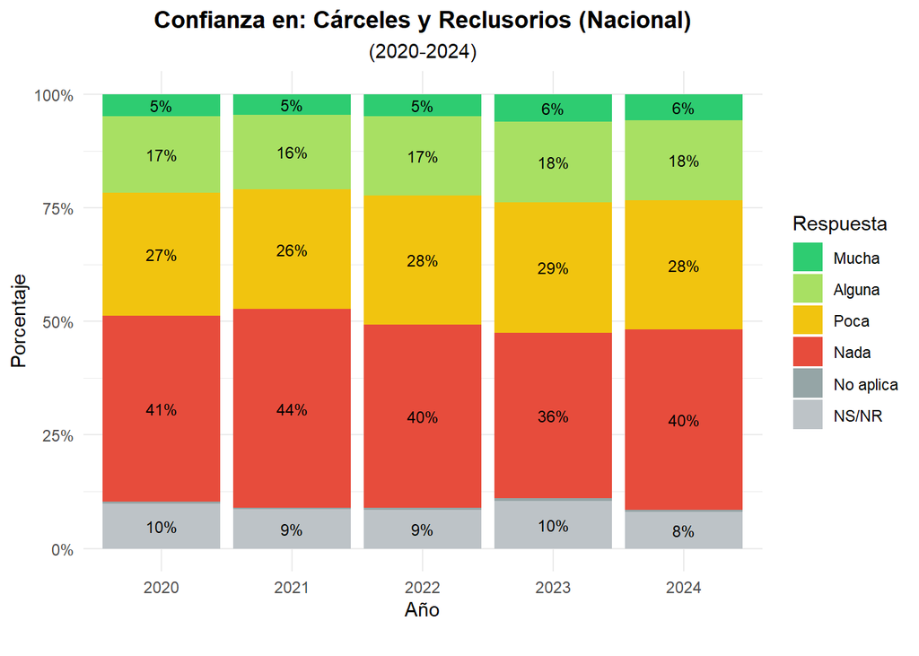

**Análisis**

Esta gráfica muestra la percepción de confianza en cárceles y reclusorios en todo el país.

A nivel nacional, las respuestas de “nada de confianza” son las más altas durante todos los años analizados. En algunos años incluso superan el 40% de las respuestas, lo que refleja una percepción negativa generalizada hacia estas instituciones.

Las categorías de “mucha” confianza permanecen muy bajas, alrededor del 5% o 6%, lo que indica que solo una pequeña parte de la población tiene una opinión claramente positiva.

También se observa una ligera mejora en 2023, cuando disminuye el porcentaje de personas que respondieron “nada de confianza”. Sin embargo, en 2024 esta categoría vuelve a aumentar.

Comparando con Querétaro, el estado presenta niveles de confianza ligeramente mejores que el promedio nacional, ya que tiene menores porcentajes de “nada de confianza” y mayores porcentajes de “alguna” confianza en varios años.

En conjunto, la gráfica refleja que la desconfianza hacia las cárceles y reclusorios es un fenómeno presente tanto en Querétaro como en el resto del país.

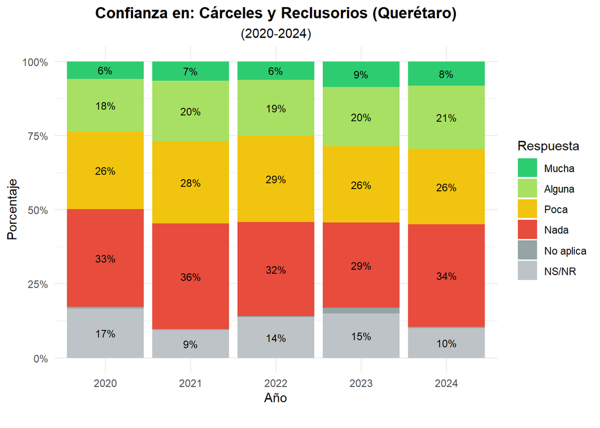

**Análisis**

Esta gráfica presenta la distribución de respuestas de la población de Querétaro sobre la confianza en cárceles y reclusorios.

Durante todo el periodo, las respuestas de “poca” y “nada” de confianza fueron las más frecuentes. Esto indica que una gran parte de la población mantiene una percepción negativa sobre las cárceles y reclusorios.

Sin embargo, también se observa una ligera mejora entre 2020 y 2023, ya que aumentaron un poco las respuestas de “alguna” y “mucha” confianza, mientras disminuyeron las de “nada” de confianza.

En 2024 vuelve a observarse un incremento en la categoría “nada de confianza”, lo que sugiere que la percepción positiva no logró consolidarse completamente.

En términos generales, la gráfica muestra que la confianza ciudadana hacia estas instituciones continúa siendo baja en Querétaro, aunque con algunos periodos de mejora temporal.

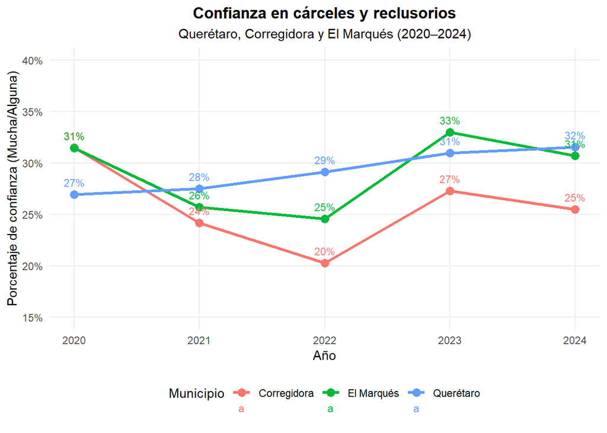

**Nota:** Los datos expuestos en la gráfica correspondiente a el municipio de El Marqués anteriores al año 2024 no representan con exactitud la información esperada, esto debido a la muestra tomada para el ENVIPE en sus ediciones 2021, 2022, 2023 y 2024, donde si bien El Marqués se considera una Área Urbana de Interés existe una diferencia abismal en el número de datos recopilados en estos años a los recopilados en 2025, pasando de una a once localidades principales para la alta de datos, lo que para los años anteriores a la ENVIPE 2025 significa menos cantidad de datos y a su vez anomalías al aplicar su factor de expansión correspondiente.

**Análisis**

La gráfica muestra el nivel de confianza en las cárceles y reclusorios en los municipios de Querétaro, Corregidora y El Marqués entre 2020 y 2024.

Se observa que:

- En general, los niveles de confianza se mantuvieron entre el 20% y el 33%, es decir, aproximadamente solo 2 o 3 de cada 10 personas señalaron tener “mucha” o “alguna” confianza en las cárceles y reclusorios.
- Corregidora presentó la disminución más marcada entre 2020 y 2022, pasando de 31% a 20%. Aunque hubo una recuperación en 2023, en 2024 el porcentaje volvió a bajar ligeramente.
- Querétaro mostró un comportamiento más estable y con una ligera tendencia al aumento. Después de iniciar en 27% en 2020, alcanzó 32% en 2024, el valor más alto registrado para este municipio.
- El Marqués tuvo variaciones importantes. Luego de una disminución entre 2020 y 2022, en 2023 alcanzó su punto más alto con 33%, aunque en 2024 presentó una pequeña reducción.

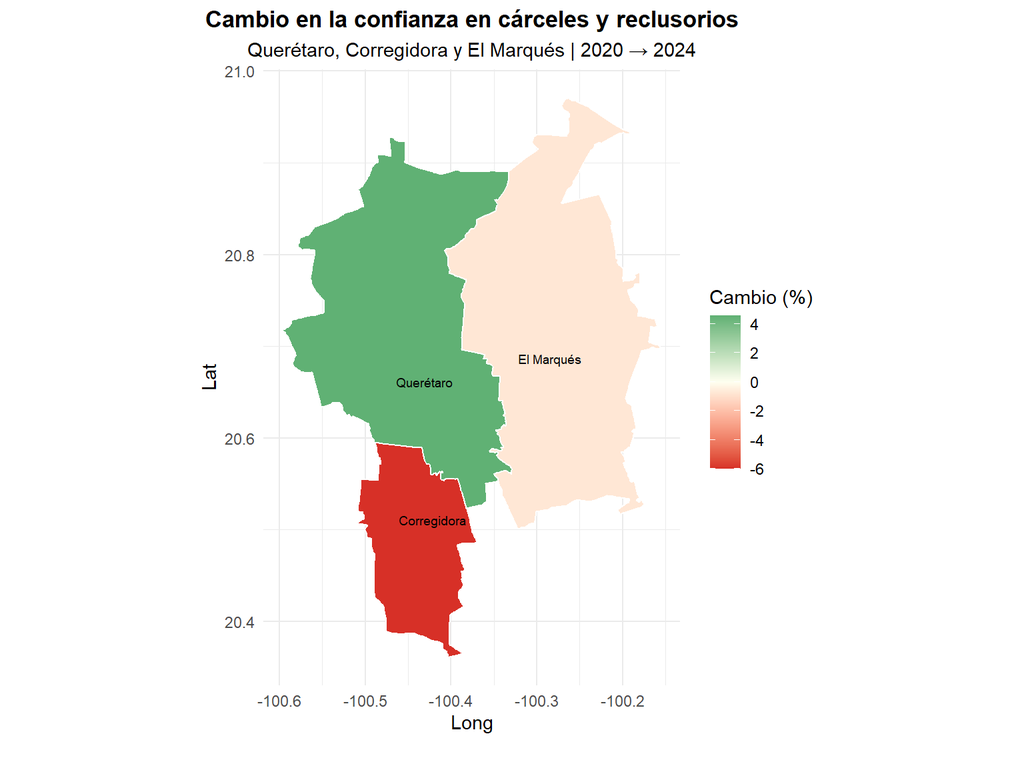

**Análisis**

La gráfica muestra cómo cambió la confianza en cárceles y reclusorios entre 2020 y 2024 en los municipios de Querétaro, Corregidora y El Marqués. Los colores verdes representan un aumento en la confianza, mientras que los tonos rojos indican una disminución.

La gráfica evidencia que la percepción sobre estas instituciones no evolucionó de la misma manera en todos los municipios. Mientras algunos mostraron mejoras, otros registraron retrocesos.

**Conclusiones**

Los resultados muestran que la confianza en cárceles y reclusorios se mantuvo relativamente baja entre 2020 y 2024 tanto a nivel nacional como en Querétaro.

La mayor parte de la población se concentró en las categorías de “poca” o “nada” de confianza, lo que refleja una percepción mayormente negativa hacia estas instituciones. En contraste, las respuestas de “mucha” confianza representaron porcentajes reducidos durante todo el periodo analizado.

Aunque en algunos años se observaron ligeras mejoras, especialmente entre 2022 y 2023, estas no se mantuvieron completamente en 2024.

A nivel municipal, los resultados muestran diferencias importantes. Mientras el municipio de Querétaro presentó una mejora moderada en la percepción, Corregidora registró disminuciones y El Marqués mostró cambios más variables.

En conjunto, las gráficas sugieren que las cárceles y reclusorios continúan siendo instituciones que generan desconfianza entre gran parte de la población, aunque también se observan pequeñas señales de mejora en algunos municipios.

## Conclusión Final

A lo largo de este recorrido por los datos de la ENVIPE, lo que hemos visto es que la seguridad pública no es solo una cuestión de números o de listas de delitos. Detrás de cada porcentaje hay personas que cambian su forma de vivir, que sienten miedo, que dejan de confiar en las autoridades o que, por el contrario, encuentran refugio en sus amistades y familiares. El análisis de los últimos cinco años, de 2020 a 2024, nos muestra un país con luces y sombras, y un estado como Querétaro que, aunque suele considerarse más tranquilo, también presenta señales que merecen atención.

Empecemos por lo que la gente espera del futuro. En todo México, la sensación de que la seguridad va a mejorar ha crecido un poco, pero sigue siendo una opinión minoritaria. La mayoría aún cree que las cosas se mantienen igual de mal o que incluso van a empeorar. En Querétaro, esa desconfianza hacia el futuro incluso aumentó hacia 2024, sobre todo en municipios como Corregidora y El Marqués, donde mucha gente terminó pensando que la situación se pondría peor. Esto es importante porque lo que la gente espera termina afectando su comportamiento: si se cree que va a haber más delincuencia, se evita salir, se desconfía del vecino o se toman medidas extremas que terminan desgastando la vida en comunidad.

En cuanto a los delitos que más afectan la vida diaria, como los robos en la colonia o los robos de auto, las tendencias no son parejas. A nivel nacional, un poco menos de gente reportó problemas de robos en su localidad al final del periodo, pero en Querétaro ocurrió lo contrario: más personas dijeron haber sufrido o visto robos cerca de su casa. Algo parecido pasó con los robos de vehículos, que aumentaron en números absolutos en todo el país, pero en Querétaro ese aumento fue más notorio. Esto quiere decir que, aunque en promedio el país mejore ligeramente en algunos indicadores, hay regiones donde la inseguridad se siente cada vez más cerca.

Hay delitos que, afortunadamente, son poco frecuentes, pero cuando ocurren dejan una huella muy profunda. El secuestro es uno de ellos. En México el número total de secuestros se mantuvo más o menos estable, pero en Querétaro la tasa creció de manera importante. No se trata de miles de casos, sino de que la tendencia va al alza, y eso es suficiente para generar alarma. Algo parecido ocurre con la desaparición forzada: los porcentajes son muy pequeños, pero el hecho de que aparezcan todos los años, en todas las regiones, indica que es un problema real que no se ha resuelto. Además, estados como Jalisco presentaron niveles mucho más altos que Querétaro, lo que demuestra que la gravedad del problema varía mucho de un lugar a otro.

Uno de los hallazgos más claros de este análisis es la enorme diferencia entre la confianza que la gente tiene en sus amigos y la que tiene en las instituciones. Prácticamente ocho de cada diez personas en Querétaro dijeron tener mucha o algo de confianza en sus amistades, una cifra que se mantuvo firme durante todo el periodo. Esa red de apoyo es fundamental para sobrellevar la inseguridad. Pero cuando se pregunta por las cárceles y reclusorios, la historia es completamente distinta: solo entre dos y tres de cada diez personas confían en ellos, y esa desconfianza se mantuvo alta durante los cinco años. Esto refleja una percepción muy extendida de que el sistema penitenciario no funciona, que no rehabilita o que incluso es parte del problema.

Otro dato que llama la atención es que muy poca gente sabe de operativos contra la delincuencia en su propia localidad. Menos del treinta por ciento de la población nacional y estatal dijo tener conocimiento de que se hubieran realizado. En Querétaro ese porcentaje mejoró un poco, de 21% a 27%, pero sigue siendo bajo. Si la gente no ve a las autoridades actuar, es muy difícil que confíe en ellas. La seguridad no solo tiene que hacerse, también tiene que ser visible y entendible para la ciudadanía.

Curiosamente, la preocupación por la economía del país bajó significativamente en estos años. Al inicio del periodo, cerca del setenta por ciento de la población estaba muy preocupada por temas como el desempleo, la pobreza o el aumento de precios; hacia el final, esa cifra cayó a alrededor del sesenta por ciento. En Querétaro pasó de 70% a 57%. No es que la economía haya dejado de importar, sino que parece que otros miedos, como la inseguridad o la corrupción, han ido ganando espacio en la mente de la gente. Eso no es necesariamente una buena noticia, porque significa que la delincuencia se está volviendo una preocupación central.

En resumen, lo que este recorrido por la ENVIPE nos deja ver es que la seguridad no puede medirse solo con estadísticas de delitos. Hay que mirar también lo que la gente siente, lo que espera, en quién confía y qué tanto ve al Estado actuar. Querétaro, a pesar de ser un estado con índices delictivos relativamente bajos comparado con otras regiones, muestra señales de desgaste en la confianza y un aumento en algunos miedos y delitos. Las relaciones personales siguen siendo un refugio importante, pero eso no es suficiente si las instituciones no logran hacerse presentes y generar credibilidad. Al final, la seguridad pública es, sobre todo, una experiencia ciudadana: la de poder caminar tranquilo, la de no tener miedo al salir de casa, la de sentir que las autoridades responden. Y esos son aspectos que los números por sí solos nunca terminan de contar.

## Referencias

Allaire, J., Xie, Y., Dervieux, C., McPherson, J., Luraschi, J., Ushey, K., Atkins, A., Wickham, H., Cheng, J., Chang, W., Iannone, R. (2025). *rmarkdown: Dynamic Documents for R* (Version 2.30) [R package]. https://github.com/rstudio/rmarkdown

Instituto Nacional de Estadística y Geografía. (2025). *Encuesta Nacional de Victimización y Percepción sobre Seguridad Pública (ENVIPE) 2025: Diseño muestral.* https://www.inegi.org.mx/contenidos/programas/envipe/2025/doc/889463926689.pdf

Instituto Nacional de Estadística y Geografía. (2025). *Encuesta Nacional de Victimización y Percepción sobre Seguridad Pública (ENVIPE) 2025: Estructura de la base de datos.* https://www.inegi.org.mx/contenidos/programas/envipe/2025/doc/fd_envipe2025.pdf

Instituto Nacional de Estadística y Geografía. (2025). *Encuesta Nacional de Victimización y Percepción sobre Seguridad Pública (ENVIPE) 2025: Informe operativo.* https://www.inegi.org.mx/contenidos/programas/envipe/2025/doc/889463926665.pdf

Instituto Nacional de Estadística y Geografía. (2025). *Encuesta Nacional de Victimización y Percepción sobre Seguridad Pública (ENVIPE) 2025: Marco conceptual.* https://www.inegi.org.mx/contenidos/programas/envipe/2025/doc/889463926672.pdf

Instituto Nacional de Estadística y Geografía. (2021). *Encuesta Nacional de Victimización y Percepción sobre Seguridad Pública (ENVIPE) 2021: Microdatos* [Conjunto de datos]. INEGI.

Instituto Nacional de Estadística y Geografía. (2022). *Encuesta Nacional de Victimización y Percepción sobre Seguridad Pública (ENVIPE) 2022: Microdatos* [Conjunto de datos]. INEGI.

Instituto Nacional de Estadística y Geografía. (2023). *Encuesta Nacional de Victimización y Percepción sobre Seguridad Pública (ENVIPE) 2023: Microdatos* [Conjunto de datos]. INEGI.

Instituto Nacional de Estadística y Geografía. (2024). *Encuesta Nacional de Victimización y Percepción sobre Seguridad Pública (ENVIPE) 2024: Microdatos* [Conjunto de datos]. INEGI.

Instituto Nacional de Estadística y Geografía. (2025). *Encuesta Nacional de Victimización y Percepción sobre Seguridad Pública (ENVIPE) 2025: Microdatos* [Conjunto de datos]. INEGI.

Posit Team. (2026). *RStudio* (Version 2026.1.0.392) [Software]. https://posit.co/

R Core Team. (2025). *R: A language and environment for statistical computing* (Version 4.5.1) [Software]. R Foundation for Statistical Computing. https://www.r-project.org/